# MAPS

### YOUR TURN #1

```r
library(tidyverse)
```

#### Q: Use ggplot2 and pull out map data for all US counties: `counties <- map_data("county")`

```r
counties <- map_data("county")
```

#### Q: Draw a map of counties (polygons & path geom)

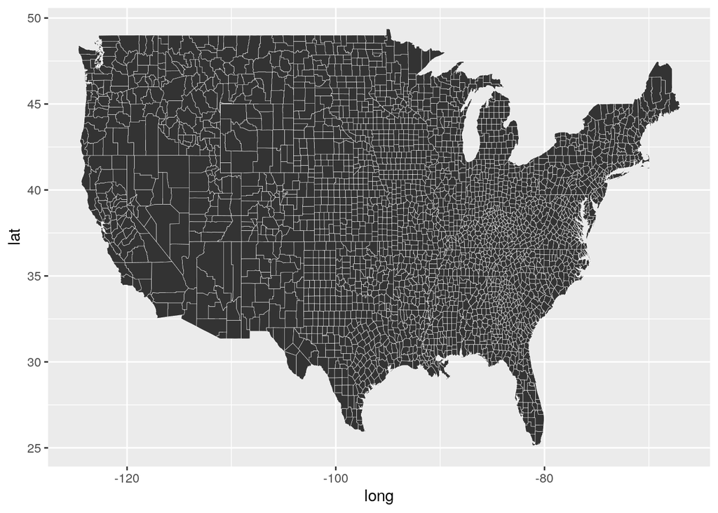

```r
counties %>%
  ggplot(aes(x = long, y = lat)) +
  geom_polygon(aes(group=group), size=.1, colour="white")
```

#### Q: Colour all counties called “story”

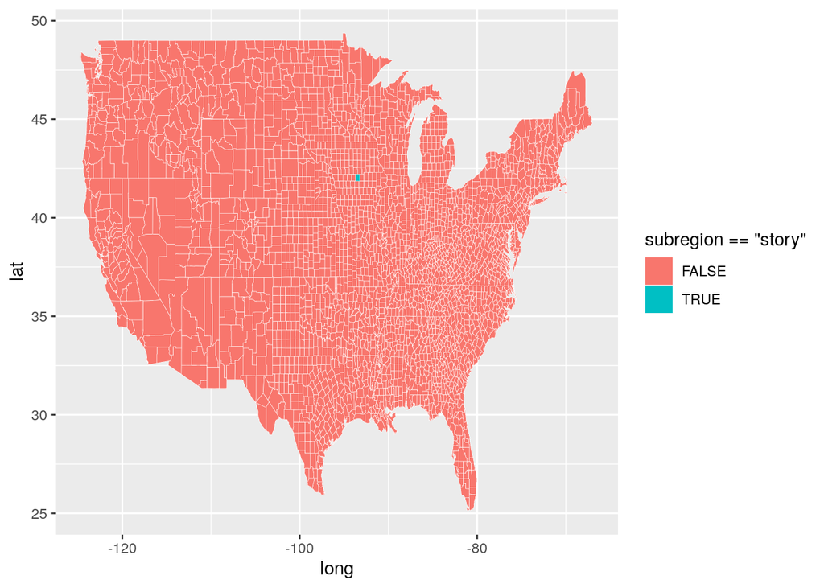

```r
counties %>%
  ggplot(aes(x = long, y = lat)) +
  geom_polygon(aes(group = group, fill = subregion == "story"), size = .1, colour = "white")
```

```r
#
#
# counties %>%
#   mutate(filled = subregion == "story") %>%
#   ggplot(aes(x = long, y = lat)) +
#   geom_polygon(aes(group = group, fill = filled), size = .1, colour = "white")
```

#### Q: Advanced: What county names are used most often?

Identify the counties:

```r
counties %>% count(subregion) %>% arrange(desc(n)) # counts multiples
```

```
## # A tibble: 1,777 x 2
##    subregion      n
##    <chr>      <int>
##  1 washington  1121
##  2 jefferson    888
##  3 franklin     719
##  4 jackson      683
##  5 madison      642
##  6 lincoln      614
##  7 union        507
##  8 monroe       479
##  9 marion       467
## 10 grant        443
## # … with 1,767 more rows
```

```r
counties %>%
  distinct(region, subregion) %>%
  count(subregion) %>%
  arrange(desc(n))
```

```
## # A tibble: 1,777 x 2
##    subregion      n
##    <chr>      <int>
##  1 washington    32
##  2 jefferson     26
##  3 franklin      25
##  4 jackson       24
##  5 lincoln       24
##  6 madison       20
##  7 clay          18
##  8 montgomery    18
##  9 union         18
## 10 marion        17
## # … with 1,767 more rows
```

Look at those countries on the map:

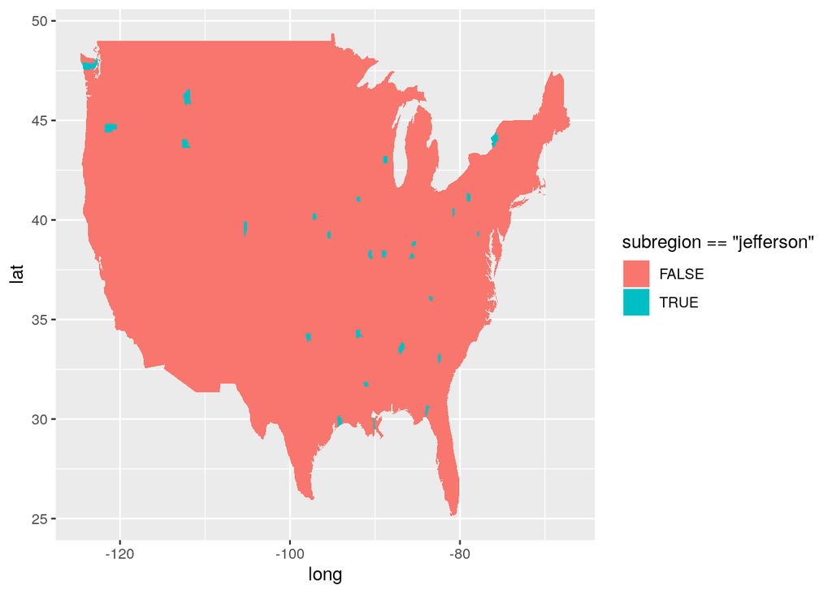

```r
counties %>%
  ggplot(aes(x = long, y = lat)) +
  geom_polygon(aes(group = group, fill= subregion == "jefferson"))
```

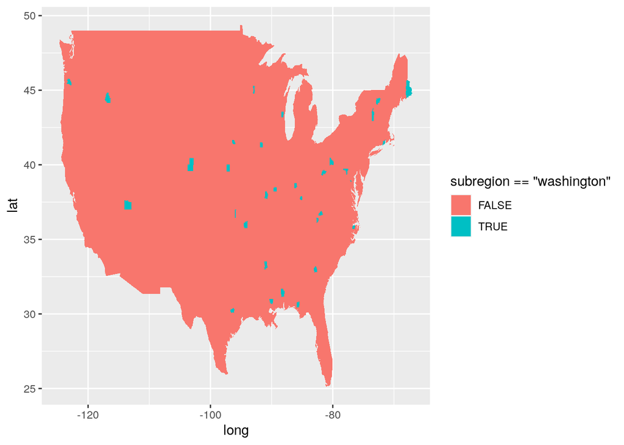

```r
ggplot(counties, aes(x = long, y = lat)) +
  geom_polygon(aes(group = group, fill = subregion == "washington"))
```

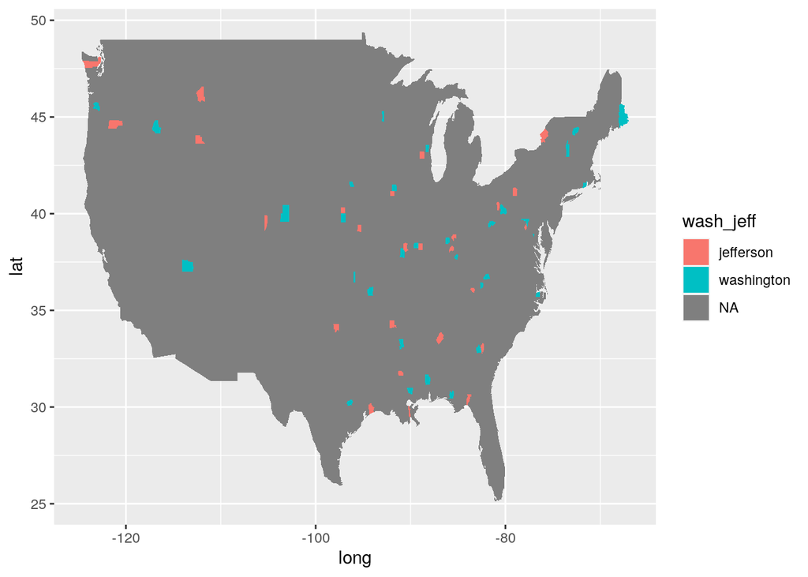

```r
counties %>%
  mutate(wash_jeff = replace(subregion, !(subregion %in% c("jefferson", "washington")), NA)) %>% # arrange(wash_jeff)
  ggplot(aes(x = long, y = lat)) +
  geom_polygon(aes(group=group, fill= wash_jeff))
```

### YOUR TURN #2

For this question use `usa_sf()` from the `albersusa` package to retreive a U.S. state composite map as a shapefile. (run the code below)

```r
# devtools::install_github("hrbrmstr/albersusa")
library(albersusa)
states_sf <- usa_sf()
```

#### Q: Use geom_sf() and the states data to create a map of the US.

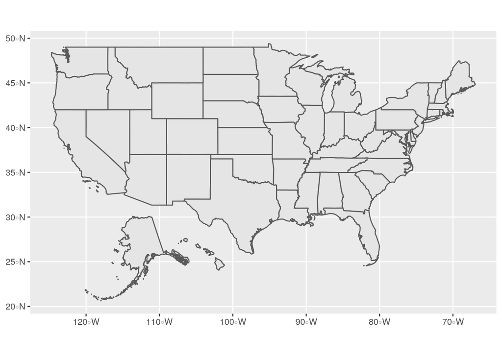

```r
library(sf)
ggplot(data = states_sf) + geom_sf()
```

### YOUR TURN #3

```r
data(fbi, package="classdata")
```

#### Q: Draw a choropleth map of the rate of motor vehicle thefts in 2012 across the US.

#### Q: `scale_fill_gradient2()` allows you to set a color scheme with two main colors. Read up on it and change the scheme in the first choropleth map.

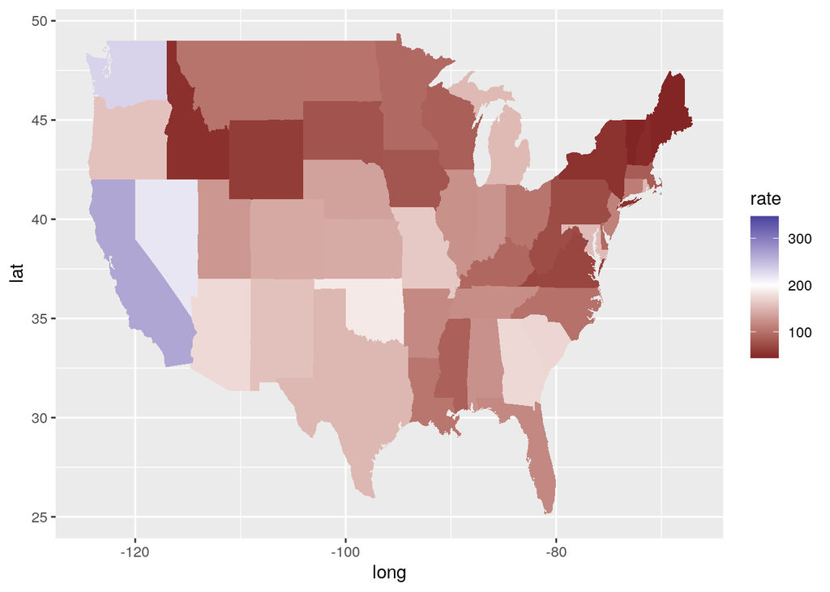

```r
states <- map_data("state")
library(classdata)

fbi.map <- fbi %>%
  filter(Year==2012) %>%
  mutate(region = tolower(State),
         rate = Count/Population*60000) %>%
  left_join(states, by="region")

fbi.map %>%
  filter(Type=="Motor.vehicle.theft") %>%
  ggplot(aes(x = long, y = lat)) +
  geom_polygon(aes(group = group, fill = rate))+
  scale_fill_gradient2(midpoint=200)
```

### YOUR TURN #4

```r
acc <- read.csv("https://raw.githubusercontent.com/DS202-at-ISU/labs/master/data/fars2016/accident.csv", stringsAsFactors = FALSE)
```

#### Q: Use the accident data to plot the geographic location of all accidents in the US in 2016.

#### Q: Plot accidents on a map of the US (use the map of the US as first layer)

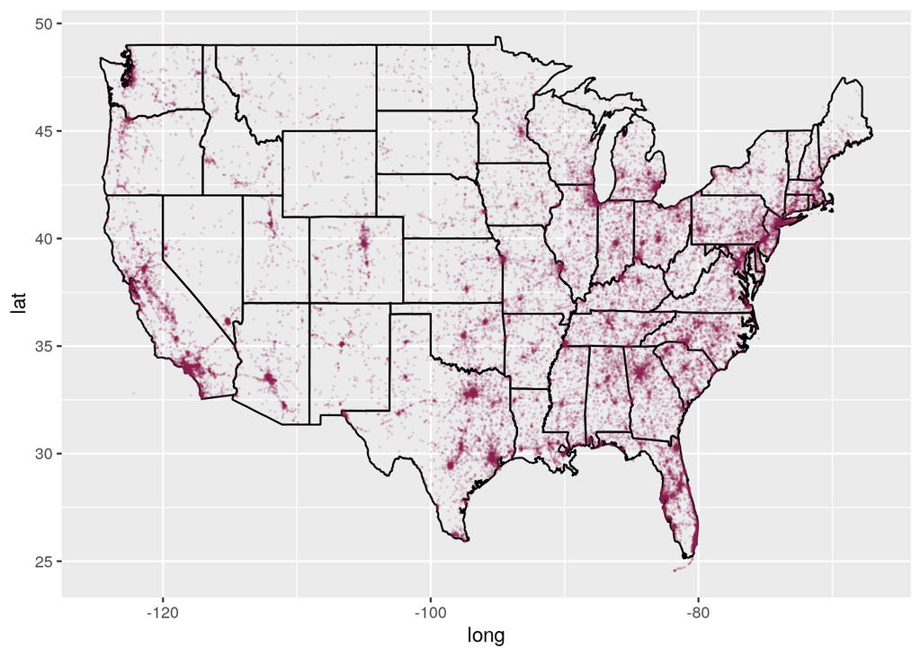

```r
states %>%
  ggplot(aes(x = long, y=lat)) +
  geom_path(aes(group=group)) +
  geom_point(data=filter(acc, between(LONGITUD, -130, 700)),
             aes(x = LONGITUD, y=LATITUDE),
             size = .1, alpha=.1, color = "violetred4"
             )
```

#### Q: Why would it be tricky to plot a choropleth map of the number of accidents by state?

### YOUR TURN #5

#### Q: The numbers for each state (`STATE`) are so-called fips codes.

#### Q: Sketch out the steps necessary to draw a choropleth map of the rate of fatal accidents by state.

```r
states_sf <- usa_sf()
states_modified <- states %>%
  mutate(STATE = as.numeric(as.character(states$fips_state)))
acc_mod <- acc %>%
  group_by(STATE) %>%
  mutate(count = n()) %>%
  left_join(states_modified, by="STATE")

acc_mod %>%
  #filter(between(LONGITUD, -130, 700)) %>%
  ggplot() +
  geom_sf(aes(fill = count))
```

[output not shown]